# **Desigualdade de Renda: Uma análise para as mesorregiões e microrregiões do Estado da Paraíba**

Autor

Evandro Farias Rocha

Resumo

## Introdução

O Fórum Celso Furtado de Desenvolvimento da Paraíba sediará no mês de julho de 2024 o **Seminário III: Interiorização do Desenvolvimento da Paraíba**, cujo objetivo é promover o debate sobre a realidade socioeconômica da Paraíba e apontar perspectivas, desafios e soluções para um processo de interiorização voltado para o desenvolvimento inclusivo e sustentável. Na oportunidade serão discutidos temas envolvendo concentração da renda, dispersão socioeconômica e produtiva, desenvolvimento com inclusão e sustentabilidade. Espera-se, ao final do seminário, que surjam propostas e projetos norteadores de ações e planos de governos estadual e municipais alinhados com o novo paradigma do desenvolvimento sustentável.

O debate sobre as disparidades regionais e a concentração de renda tem alcançado relevante destaque no Brasil. Não obstantes as condições históricas de sua formação e as condições estruturais, marcadas por distorções na distribuição setorial e espacial da renda, o país conseguiu, principalmente nas três últimas décadas, melhorar seus indicadores socioeconômicos e apresentar taxas positivas de crescimento. Essas mudanças decorreram, em parte, em razão das políticas públicas de transferência de rendas, aumento real da renda do trabalho, investimentos em obras estruturantes e implementações de políticas anticíclicas que minimizaram os efeitos e pressões de crises internas e externas. Contudo, mesmo com o país retomando a agenda do crescimento, problemas na distribuição de renda regional e intra-regional ainda persiste, e em alguns casos até se agravaram.

A questão regional brasileira está bem fundamentada na obra de Celso Furtado. Na construção de sua teoria, Celso Furtado desenvolveu uma concepção histórico-estrutural que possibilitou compreender a problemática do subdesenvolvimento, suas causas e formas de superação, descolada dos modelos teóricos tradicionais. Para Furtado

> > > (…) as mudanças espaciais dependem, fundamentalmente, de quatro fatores, a saber: a) do ritmo de crescimento econômico, cujo aumento possibilita maior elasticidade espacial; b) do número de novas plantas, especialmente de plantas motrizes; c) das plantas de processamento secundário, não dependentes de insumos e matérias-primas primárias; d) das economias de escala, as quais se ampliam com o progresso técnico (DINIZ, 2020, p. 321).

Este trabalha apresenta uma análise da distribuição espacial do PIB e do PIB per capita para as mesorregiões e microrregiões do Estado da Paraíba, para os anos de 2010 e 2021. Optou-se pelo indicador de medida de dispersão de Williamson (1977) para medir o grau de desigualdade e dispersão entre as regiões da Paraíba.

## 1. O PIB e o PIB per capita na Paraíba

O estado da Paraíba é formado por 223 municípios divididos geograficamente em quatro mesorregiões e 23 microrregiões. Seu espaço territorial compreende uma área terrestre de 56.469 km², equivalente a 3,62% do Nordeste e 0,67% do Brasil. Segundo o último Censo Demográfico do IBGE, ano base 2022, a população residente da Paraíba totalizou 3.974.687 habitantes, apresentando um crescimento de 5,5% (0,45% a.a.) em relação ao ano de 2010, que representava 3.766.834 habitantes. Em 2021, estado gerou um PIB de R$ 77.470 bilhões (a preços correntes). Esse valor representa um crescimento de 131% em relação aos R$ 33.522 bilhões registrados em 2010. A preços constantes, tomando-se como referência o ano de 2021, o crescimento real do PIB foi de 14%. No mesmo período, o PIB per capita, a preços contantes de 2021, saiu de R$ 18.049,00 para R$ 19.082,00, um crescimento de 5,7% para o período.

O mapa abaixo apresenta a distribuição espacial do PIB paraibano por mesorregião em 2021. Como pode ser observado, a região da Mata Paraibana tem posição destacada, concentrando 51% do PIB do estado. Em 2010 essa região respondia por 51.6% do PIB, praticamente a mesma participação observado em 2021.

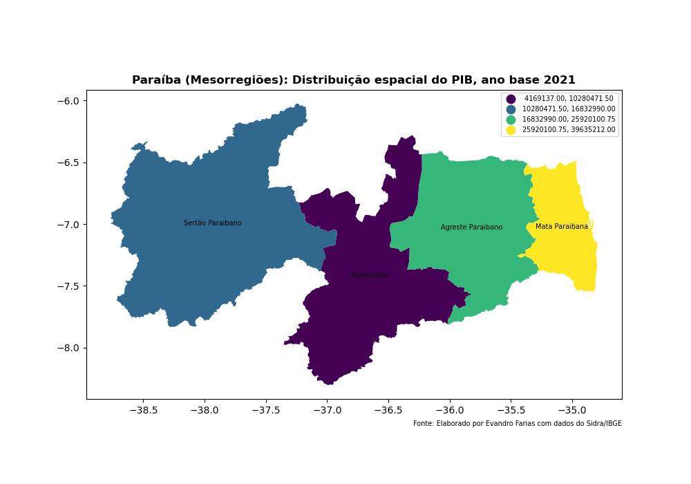

A Tabela 1 apresenta a distribuição espacial do PIB paraibano para as mesorregiões do estado da paraíba nos anos de 2010 e 2021. Os dados revelam que, passado uma década, a participação relativa das mesorregiões no PIB paraibano permaneceu praticamente a mesma. Polari (2012) destaca que, nas últimas décadas, a economia paraibana vem se concentrando na região metropolitana de João Pessoa. Para o autor, “a elevada concentração da riqueza, da renda e da propriedade e posse da terra é um dos aspectos que atuam permanentemente como causas e efeitos básicos do subdesenvolvimento” (POLARI, 2012, p. 321).

Tabela 1: Mesorregiões da Paraíba

Distribuição espacial do PIB e PIB per capita

[output not shown]

Fonte: IBGE/SIDRA  
Nota: PIB a preços correntes

### Microrregiões

O estado da Paraíba é formado por 23 microrregiões classificadas pelo IBGE com base nas similaridades econômicas e sociais de cada município. O Mapa a seguir apresenta a distribuição espacial do PIB para o ano 2021 nas microrregiões do Estado.

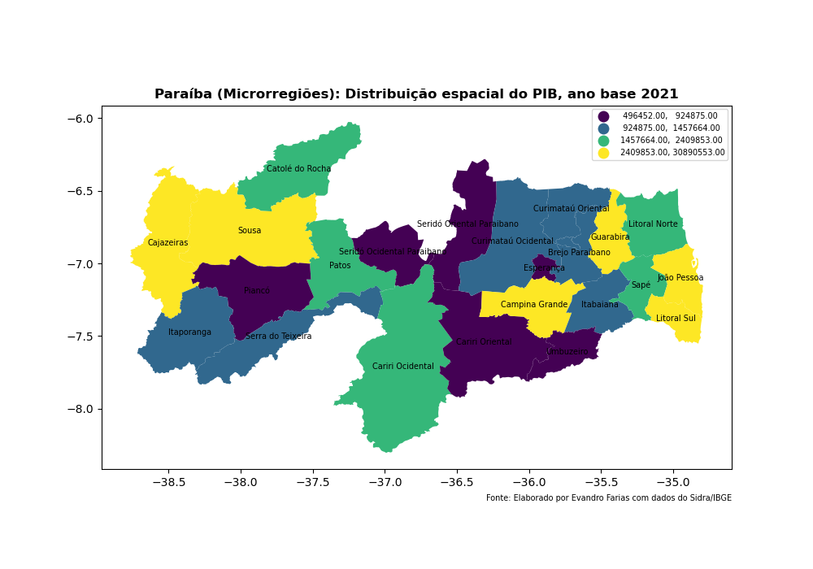

Tabela 2: Microrregiõe da Paraíba e PIB per capita

Distribuição espacial do PIB

| Microrregião | 2010 |  |  | 2021 |  |  |
| --- | --- | --- | --- | --- | --- | --- |
|  | PIB_10 | pct_10 | PIB_pc_10 | PIB_21 | pct_21 | PIB_pc_21 |
| João Pessoa | 14855518.0 | 44.32 | 13,637.95 | 30890553.0 | 39.87 | 28,764.84 |
| Campina Grande | 5665249.0 | 16.90 | 7,409.05 | 11939764.0 | 15.42 | 14,664.95 |
| Sousa | 1155334.0 | 3.43 | 5,147.50 | 2791744.0 | 3.61 | 12,048.94 |
| Cajazeiras | 1115687.0 | 3.34 | 5,304.68 | 2522302.0 | 3.24 | 11,623.92 |
| Guarabira | 995917.0 | 2.97 | 5,067.42 | 2978417.0 | 3.85 | 12,007.95 |
| Patos | 964941.0 | 2.88 | 5,538.55 | 2297404.0 | 2.95 | 12,154.15 |
| Litoral Norte | 913371.0 | 2.72 | 6,258.97 | 2205056.0 | 2.85 | 13,335.63 |
| Litoral Sul | 885528.0 | 2.64 | 10,582.44 | 4853694.0 | 6.27 | 58,461.49 |
| Brejo Paraibano | 675148.0 | 2.02 | 6,298.65 | 1457664.0 | 1.88 | 12,741.53 |
| Sapé | 660160.0 | 1.96 | 4,787.84 | 1685909.0 | 2.18 | 11,966.60 |
| Cariri Ocidental | 648380.0 | 1.94 | 5,344.03 | 1698123.0 | 2.18 | 12,045.84 |
| Catolé do Rocha | 639930.0 | 1.91 | 5,031.53 | 1698171.0 | 2.19 | 12,109.29 |
| Curimataú Ocidental | 630660.0 | 1.88 | 5,173.77 | 1413887.0 | 1.81 | 10,695.31 |
| Itabaiana | 537445.0 | 1.62 | 4,908.12 | 1327895.0 | 1.70 | 11,627.01 |
| Serra do Teixeira | 507765.0 | 1.51 | 4,334.26 | 1190034.0 | 1.53 | 9,358.31 |
| Itaporanga | 423654.0 | 1.27 | 4,892.28 | 959822.0 | 1.24 | 10,389.14 |
| Curimataú Oriental | 421308.0 | 1.26 | 4,496.67 | 1003448.0 | 1.30 | 9,870.81 |
| Seridó Oriental Paraibano | 363005.0 | 1.08 | 4,984.16 | 833807.0 | 1.07 | 10,195.91 |
| Piancó | 347810.0 | 1.04 | 4,817.81 | 858106.0 | 1.11 | 11,242.23 |
| Cariri Oriental | 343928.0 | 1.02 | 5,422.31 | 889928.0 | 1.15 | 12,857.31 |
| Esperança | 324114.0 | 0.96 | 5,006.42 | 730870.0 | 0.94 | 10,637.66 |
| Umbuzeiro | 226653.0 | 0.68 | 4,223.31 | 496452.0 | 0.64 | 9,276.76 |
| Seridó Ocidental Paraibano | 220985.0 | 0.65 | 5,461.78 | 747279.0 | 0.96 | 16,625.18 |

Fonte: IBGE/SIDRA  
Nota: PIB a preços correntes

A Tabela 2 apresenta os valores do PIB das microrregiões para os anos de 2010 e 2021, com suas respectivas participações relativas. Observar-se que as microrregiões de João Pessoa e Campina Grande tiveram redução na participação relativa do PIB. A microrregião de João Pessoa, que em 2010 respondia por 44% do PIB estadual, passou para 39% em 2021. No mesmo período, a microrregião de Campina Grande reduziu sua participação de 16% para 15%. As microrregiões do Litoral Sul e de Guarabira tiveram desempenhos positivos. O Litoral Sul passou de 2,6% para 6,2% - desempenho que pode ser atribuído a implantação de uma planta industrial de cimento no município de Alhandra; e a microrregião de Guarabira, que saiu de uma participação relativa de 2,9% para 3,8%. As demais microrregiões permaneceram praticamente na mesma posição.

### O PIB per capita da Paraíba

Entre os municípios a disparidade do PIB per capita é ainda mais elevada. O mapa abaixo apresenta a distribuição espacial do PIB per capita por municípios. Como pode ser observado, o valor do PIB per capita do município de Alhandra, localizado na microrregião do Litoral Sul, foi cerca de 21 vezes maior que o ultimo colocado, Bonito de Santa Fé, localizado na microrregião de Cajazeiras. A média do PIB per capita dos municípios da Paraíba em 2021 foi R$ 13.090,91, sendo que 173 (77,5%) dos municípios apresentaram valores abaixo da média.

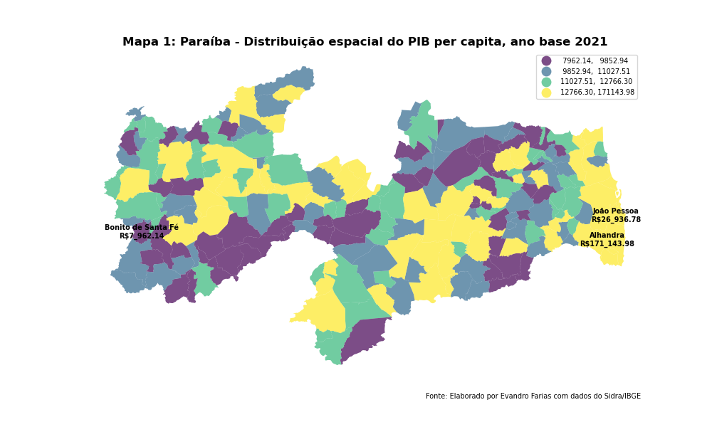

## 2. O Coeficiente de Variação de Willeamson

**O Coeficiente de Variação Ponderada de Willeamson (Vw)** é um método utilizada para mensurar a dispersão de rendimento regional per capita em relação à média estadual, considerando o desvio regional ponderado por sua participação na população estadual. O valor VW varia entre o máximo de um e o mínimo de zero, sendo que, quanto mais próximo da unidade, maiores serão as desigualdades regionais de renda per capita. A fórmula utilizada para o cálculo é a seguinte:

#### **Para as mesorregiões**

$$V_{w} = \frac{\sqrt{\sum_{i}(x_i-\bar{y})²(y_i-\bar{y})}\frac{f_i}{n}}{n}$$

Onde:

$V_{w}$ corresponde ao coeficiente de disparidades da mesorregiões  
$y_i$ é o PIB per capita da *i-ésima* do estado  
$\bar{y}$ é o PIB per capita da mesorregião  
$n$ população total da mesorregião  
$f_i$ é a população da *i-ésima* do estado.

#### **Para as microrregiões**

$$V_{w} = \frac{\sqrt{\sum_{i}(x_i-\bar{y})²(y_i-\bar{y})}\frac{f_i}{n}}{n}$$

Onde:

$V_{w}$ corresponde ao coeficiente de disparidade das microrregiões  
$y_i$ é o PIB per capita da *i-ésima* do estado  
$\bar{y}$ é o PIB per capita da microrregião  
$n$ população total da microrregião  
$f_i$ é a população da *i-ésima* do estado.

Tabela 3: Microrregiões da Paraíba: 2010 e 2021

Coeficiente de Willeamson

| Microrregião | cw_2010 | cw_2021 |
| --- | --- | --- |
| João Pessoa | 0.473 | 0.505 |
| Campina Grande | 0.337 | 0.349 |
| Sousa | 0.21 | 0.206 |
| Cajazeiras | 0.202 | 0.201 |
| Guarabira | 0.201 | 0.194 |
| Litoral Norte | 0.186 | 0.188 |
| Sapé | 0.181 | 0.18 |
| Cariri Ocidental | 0.173 | 0.171 |
| Patos | 0.174 | 0.171 |
| Curimataú Ocidental | 0.172 | 0.167 |
| Catolé do Rocha | 0.169 | 0.166 |
| Serra do Teixeira | 0.17 | 0.165 |
| Brejo Paraibano | 0.169 | 0.163 |
| Itabaiana | 0.164 | 0.16 |
| Curimataú Oriental | 0.153 | 0.144 |
| Itaporanga | 0.144 | 0.139 |
| Seridó Oriental Paraibano | 0.135 | 0.133 |
| Litoral Sul | 0.137 | 0.128 |
| Piancó | 0.132 | 0.126 |
| Cariri Oriental | 0.125 | 0.125 |
| Esperança | 0.114 | 0.114 |
| Umbuzeiro | 0.116 | 0.112 |
| Seridó Ocidental Paraibano | 0.098 | 0.094 |

Fonte: IBGE/SIDRA  
Nota: Elaborado pelo autor

## Referências

DINIZ, C. C. [Celso Furtado e o desenvolvimento regional](https://doi.org/10.7476/9786586221695.0017). Em: **Celso Furtado: a esperança militante (Interpretações): vol. 1**. [s.l.] EDUEPB, 2020. p. 305–327.

POLARI, R. **A Paraíba Que Podemos Ser: Dá crítica à ação contra o atraso**. [s.l.] Editora Universitária-UFPB, 2012.